# Genome-wide methylation analysis report

# Genome-wide methylation analysis report

- study: Pleural cfDNAm analysis of cg05575921.platevariable
- author: Paul Yousefi
- date: 08 October, 2026

## Parameters

```
## $sig.threshold
## [1] 2.121143e-07
##
## $max.plots
## [1] 10
##
## $qq.inflation.method
## [1] "median"
##
## $practical.threshold
## [1] 6.452928e-09
```

## Sample characteristics

For continuous or ordinal variables, the “mean” column provides the mean and the “sd/%” column the standard deviation of the variable. For categorical variables, the “mean” column provides the number of samples with the given “value” and the “sd/%” column the percentage of samples with the given “value”.

| variable | value | mean | sd.. |
| --- | --- | --- | --- |
| cg05575921 |  | 0.7150795 | 0.1873398 |
| plate |  | 2.319218 | 1.048991 |
| sv1 |  | 1.080671e-19 | 0.0571662 |
| sv2 |  | 1.319363e-18 | 0.0571662 |
| sv3 |  | -1.8218e-18 | 0.0571662 |
| sv4 |  | -2.070711e-18 | 0.0571662 |
| sv5 |  | 3.354582e-19 | 0.0571662 |
| sv6 |  | 3.75858e-18 | 0.0571662 |
| sv7 |  | 1.211119e-18 | 0.0571662 |
| sv8 |  | 3.13406e-15 | 0.0571662 |
| sv9 |  | 2.203524e-14 | 0.0571662 |
| sv10 |  | 2.8405e-13 | 0.0571662 |

## Covariate associations

### Covariate plate

statistics

| var1 | var2 | F | p-value | R | p-value |
| --- | --- | --- | --- | --- | --- |
| cg05575921 | plate | 0.5370642 | 0.4642148 | -0.0420152 | 0.4632616 |

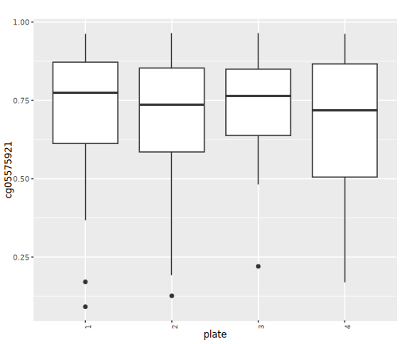

### Covariate sv1

statistics

| var1 | var2 | F | p-value | R | p-value |
| --- | --- | --- | --- | --- | --- |
| cg05575921 | sv1 | 5.798752 | 0.0166308 | -0.0244482 | 0.6694399 |

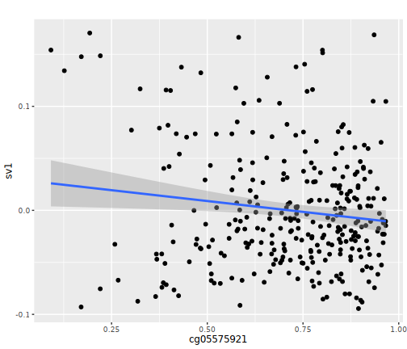

### Covariate sv2

statistics

| var1 | var2 | F | p-value | R | p-value |
| --- | --- | --- | --- | --- | --- |
| cg05575921 | sv2 | 27.72057 | 3e-07 | -0.2446485 | 1.55e-05 |

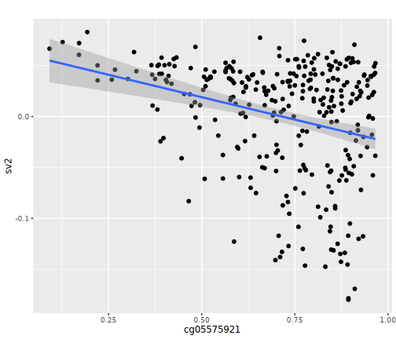

### Covariate sv3

statistics

| var1 | var2 | F | p-value | R | p-value |
| --- | --- | --- | --- | --- | --- |
| cg05575921 | sv3 | 31.50454 | 0 | 0.2575542 | 5.2e-06 |

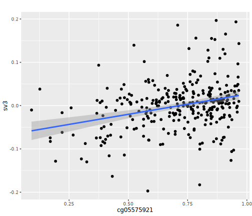

### Covariate sv4

statistics

| var1 | var2 | F | p-value | R | p-value |
| --- | --- | --- | --- | --- | --- |
| cg05575921 | sv4 | 0.0108946 | 0.9169386 | -0.0073172 | 0.898341 |

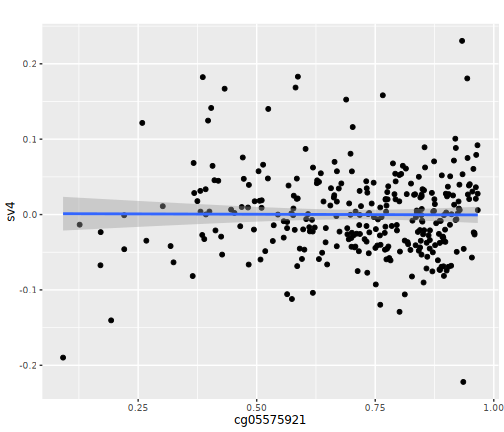

### Covariate sv5

statistics

| var1 | var2 | F | p-value | R | p-value |
| --- | --- | --- | --- | --- | --- |
| cg05575921 | sv5 | 0.0117286 | 0.9138298 | 0.0762076 | 0.1828375 |

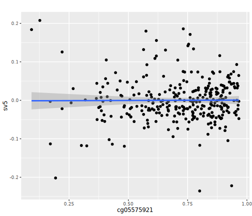

### Covariate sv6

statistics

| var1 | var2 | F | p-value | R | p-value |
| --- | --- | --- | --- | --- | --- |
| cg05575921 | sv6 | 0.7900657 | 0.3747807 | 0.036242 | 0.5267668 |

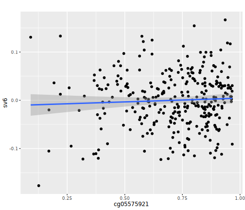

### Covariate sv7

statistics

| var1 | var2 | F | p-value | R | p-value |
| --- | --- | --- | --- | --- | --- |
| cg05575921 | sv7 | 3.241514 | 0.0727822 | 0.1203656 | 0.0350804 |

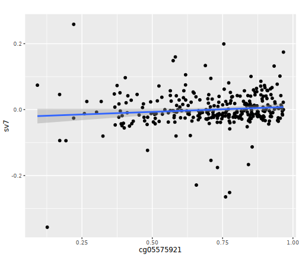

### Covariate sv8

statistics

| var1 | var2 | F | p-value | R | p-value |
| --- | --- | --- | --- | --- | --- |
| cg05575921 | sv8 | 22.89086 | 2.7e-06 | -0.2330015 | 3.93e-05 |

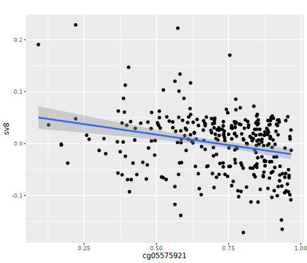

### Covariate sv9

statistics

| var1 | var2 | F | p-value | R | p-value |
| --- | --- | --- | --- | --- | --- |
| cg05575921 | sv9 | 4.278307 | 0.0394443 | 0.1406114 | 0.0137239 |

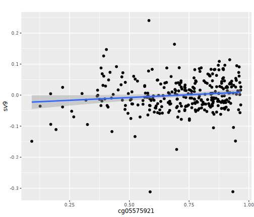

### Covariate sv10

statistics

| var1 | var2 | F | p-value | R | p-value |
| --- | --- | --- | --- | --- | --- |
| cg05575921 | sv10 | 0.3868323 | 0.5344339 | -0.0422578 | 0.4604672 |

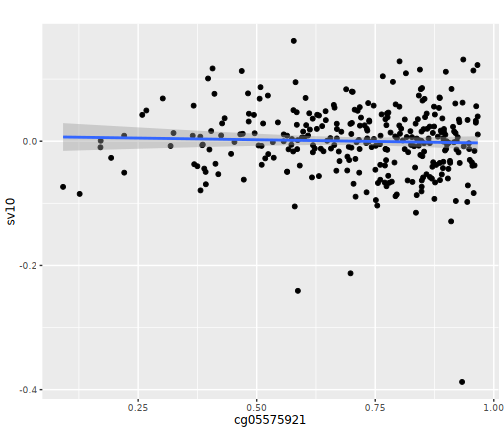

## QQ plots

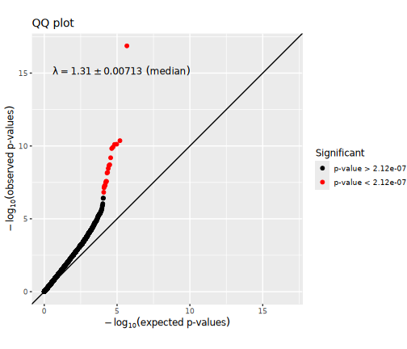

## Manhattan plots

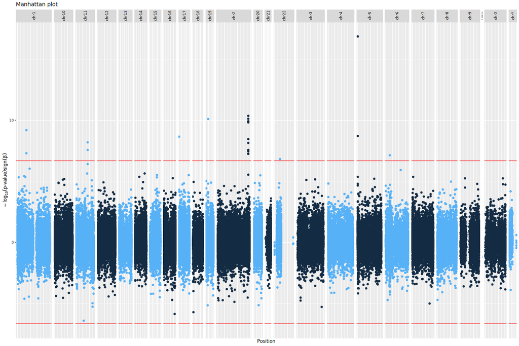

## Significant CpG sites

There were 20 CpG sites with association p-values < 2.1211427 × 10<sup>-7</sup>. These are listed in the file associations.csv.

Below are the 10 CpG sites with association p-values < 6.4529279 × 10<sup>-9</sup> in the regression model.

|  | chromosome | position | estimate | p.value | p.adjust |
| --- | --- | --- | --- | --- | --- |
| cg04284209 | chr2 | 233284334 | 0.3007614 | 0 | 0.0008259 |
| cg04284205 | chr2 | 233284296 | 0.3236040 | 0 | 0.0000179 |
| cg04284215 | chr2 | 233284427 | 0.3211326 | 0 | 0.0000103 |
| cg25648203 | chr5 | 395444 | 0.1839839 | 0 | 0.0004583 |
| cg24015091 | chr17 | 2078525 | 0.2518369 | 0 | 0.0005194 |
| cg17087741 | chr2 | 233283010 | 0.2075464 | 0 | 0.0000353 |
| cg23576855 | chr5 | 373299 | 0.5279666 | 0 | 0.0000000 |
| cg03636183 | chr19 | 17000585 | 0.2261280 | 0 | 0.0000185 |
| cg21566642 | chr2 | 233284661 | 0.2695523 | 0 | 0.0000284 |
| cg25189904 | chr1 | 68299493 | 0.3053063 | 0 | 0.0001526 |

Plots of these sites follow, one for each covariate set. “p[lm]” denotes the p-value obtained using a linear model and “p[beta]” the p-value obtained using beta regression.

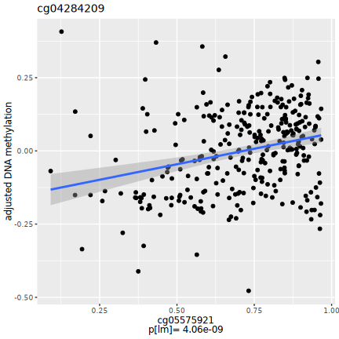

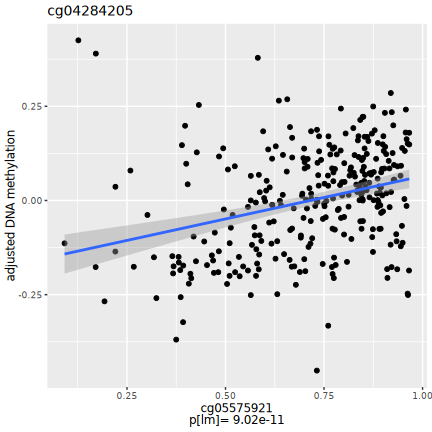

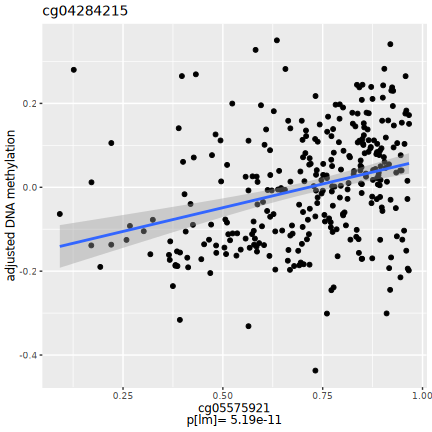

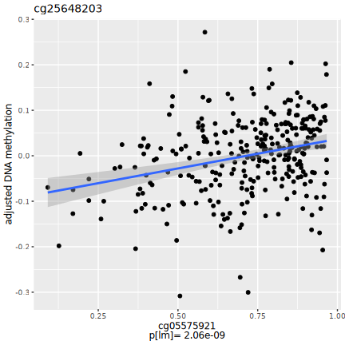

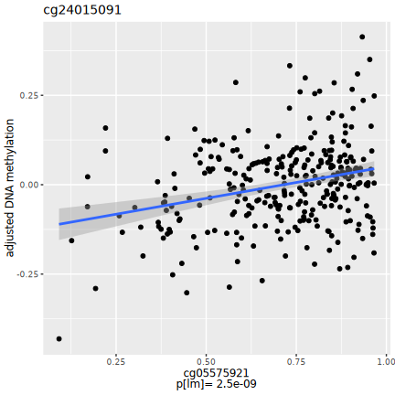

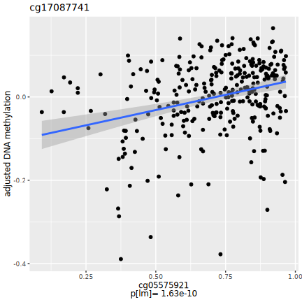

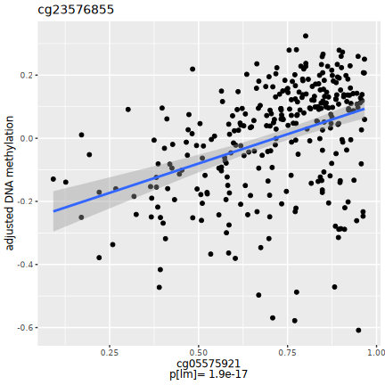

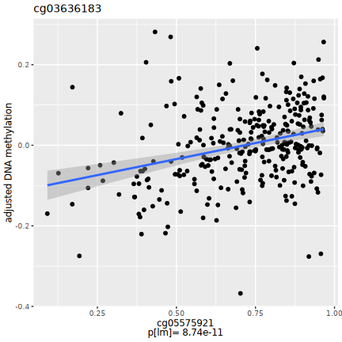

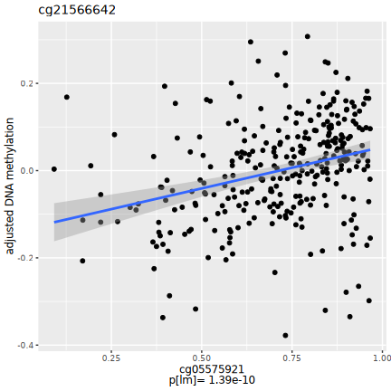

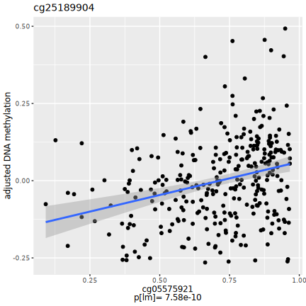

## Selected CpG sites

Number of CpG sites selected: 0.

| chromosome | position | estimate | p.value | p.adjust |
| --- | --- | --- | --- | --- |